# Exercise 7

Kyle M. Lang

Fundamental Techniques in Data Science with R

In this practical, you will work through a more complete workflow for (predictive) analytics than you have encounted in the previous practicals.

The following packages are required for this practical:

```r
library(dplyr)
library(magrittr)
library(mice)
library(ggplot2)
library(DAAG)
library(MASS)
```

# 1 Analyzing `elastic1` and `elastic2`

We will begin by analyzing the `elastic1` and `elastic2` datasets from the **DAAG** package.

## 1.1

**Visualize the data**

Use `ggplot()` to create a scatterplot of the `distance` variable against the `stretch` variable using the data from the `elastic1` and `elastic2` data frames.

- Plot both sets of points on the same graph
- Use different symbols and/or colors to differentiate the data sources
- Overlay linear regression lines for each data source
- Do not plot the standard error bands

Do the two sets of results appear consistent?

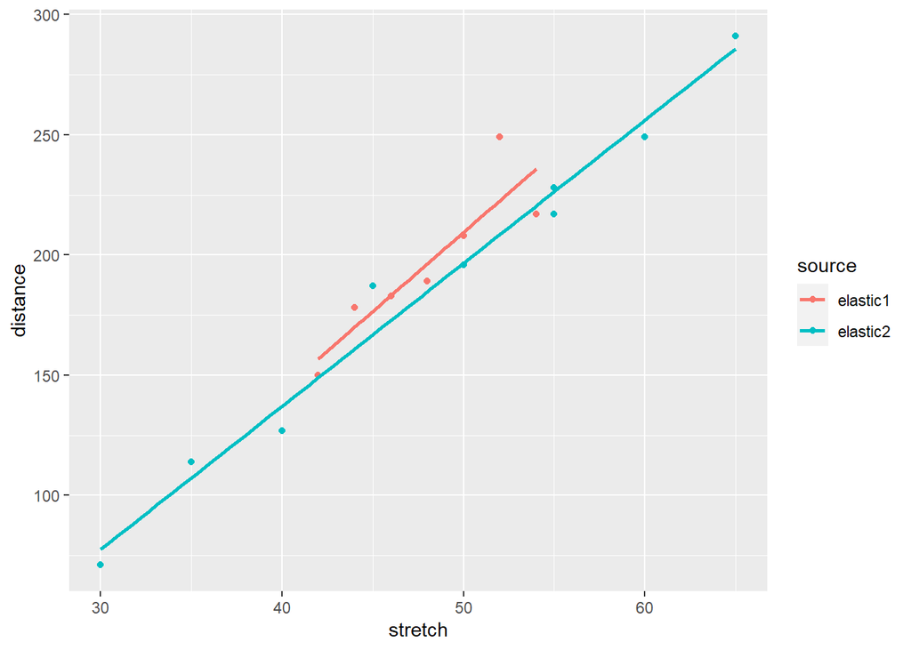

```r
elastic <- rbind(elastic1, elastic2)
elastic$source <- c(rep("elastic1", nrow(elastic1)),
                    rep("elastic2", nrow(elastic2))
                    )

elastic %>%
  ggplot(aes(stretch, distance, colour = source)) +
  geom_point() +
  geom_smooth(method = "lm", se = FALSE)
```

The results seem quite consistent. The `elastic2` dataset has more observations over a larger range, but both datasets result in similar regression lines.

## 1.2

**Estimate regression models**

For each of the data sets: `elastic1` and `elastic2`, regress `distance` onto `stretch`. Report the summary of each model and compare the following results from each model:

- The coefficient estimates
- The fitted values
- The standard errors of the residuals
- The $R^2$ statistics

What is the key difference between the two sets of data?

Estimate the two models:

```r
fit1 <- lm(distance ~ stretch, data = elastic1)
fit2 <- lm(distance ~ stretch, data = elastic2)
```

Generate the model summaries:

```r
(s1 <- summary(fit1))
```

```
##
## Call:
## lm(formula = distance ~ stretch, data = elastic1)
##
## Residuals:
##        1        2        3        4        5        6        7
##  -0.1429 -18.7143  -7.2857  -1.4286   8.0000  -6.8571  26.4286
##
## Coefficients:
##             Estimate Std. Error t value Pr(>|t|)
## (Intercept) -119.143     70.943  -1.679  0.15391
## stretch        6.571      1.473   4.462  0.00663 **
## ---
## Signif. codes:  0 '***' 0.001 '**' 0.01 '*' 0.05 '.' 0.1 ' ' 1
##
## Residual standard error: 15.59 on 5 degrees of freedom
## Multiple R-squared:  0.7992, Adjusted R-squared:  0.7591
## F-statistic: 19.91 on 1 and 5 DF,  p-value: 0.006631
```

```r
(s2 <- summary(fit2))
```

```
##
## Call:
## lm(formula = distance ~ stretch, data = elastic2)
##
## Residuals:
##      Min       1Q   Median       3Q      Max
## -10.0833  -7.0833  -0.5833   5.1667  20.1667
##
## Coefficients:
##              Estimate Std. Error t value Pr(>|t|)
## (Intercept) -100.9167    15.6102  -6.465 0.000345 ***
## stretch        5.9500     0.3148  18.899 2.89e-07 ***
## ---
## Signif. codes:  0 '***' 0.001 '**' 0.01 '*' 0.05 '.' 0.1 ' ' 1
##
## Residual standard error: 10.44 on 7 degrees of freedom
## Multiple R-squared:  0.9808, Adjusted R-squared:  0.978
## F-statistic: 357.2 on 1 and 7 DF,  p-value: 2.888e-07
```

Compare the estimated coefficients:

```r
data.frame(elastic1 = coef(fit1), elastic2 = coef(fit2))
```

```
##                elastic1  elastic2
## (Intercept) -119.142857 -100.9167
## stretch        6.571429    5.9500
```

Compare the fitted values:

```r
list(elastic1 = predict(fit1), elastic2 = predict(fit2))
```

```
## $elastic1
##        1        2        3        4        5        6        7
## 183.1429 235.7143 196.2857 209.4286 170.0000 156.8571 222.5714
##
## $elastic2
##         1         2         3         4         5         6         7         8
##  77.58333 196.58333 137.08333 166.83333 256.08333 226.33333 107.33333 226.33333
##         9
## 285.83333
```

Compare the residual standard errors:

```r
c(elastic1 = s1$sigma, elastic2 = s2$sigma)
```

```
## elastic1 elastic2
## 15.58754 10.44202
```

We see that `fit1` (based on `elastic1`) has a larger residual standard error (i.e. `summary(fit1)$sigma`).

Compare the $R^2$ values:

```r
c(elastic1 = s1$r.squared, elastic2 = s2$r.squared)
```

```
##  elastic1  elastic2
## 0.7992446 0.9807775
```

The model based on `elastic2` has a smaller residual standard error and a larger $R^2$. This better fit is due to the larger range of values in `elastic2`.

## 1.3

**Check for influential cases**

Use the `plot()` function to generate a compare the *Residual vs Leverage* plots for both of the models you estimated in Question 1.2.

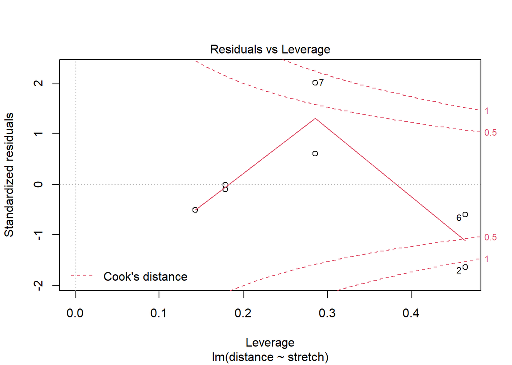

```r
plot(fit1, which = 5) # The 5th plot is the residuals vs leverage plot
```

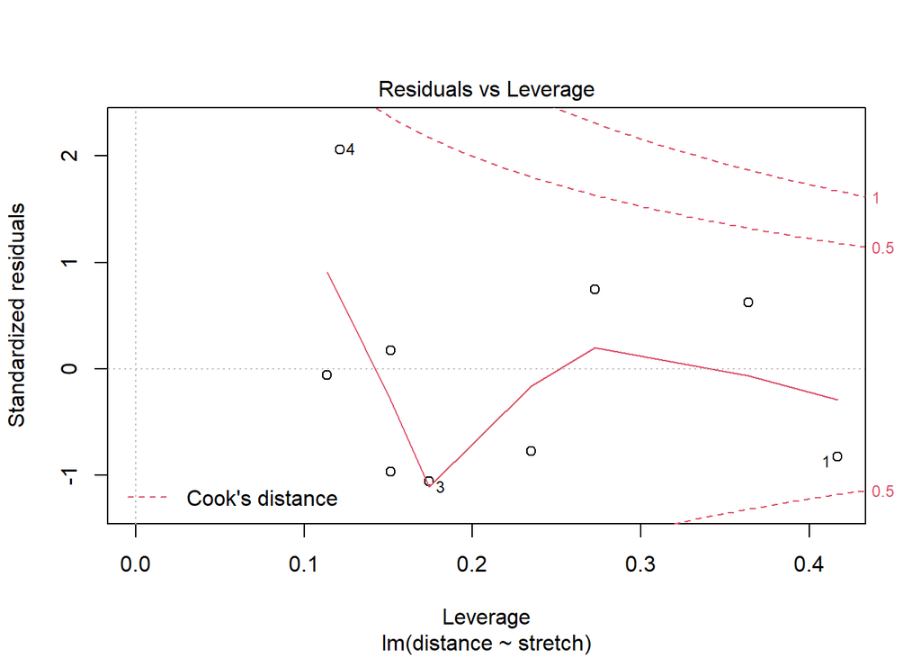

```r
plot(fit2, which = 5)
```

For `elastic1`, Case 2 has the largest influence on the estimation. However, Case 2 does not have the largest residual:

```r
## Extract estimated residuals:
fit1$residuals
```

```
##           1           2           3           4           5           6
##  -0.1428571 -18.7142857  -7.2857143  -1.4285714   8.0000000  -6.8571429
##           7
##  26.4285714
```

Case 7 has the largest residual, but Case 2 is most influential because it has both a relatively large residual and also a high leverage value.

```r
## Compute leverage values:
hatvalues(fit1)
```

```
##         1         2         3         4         5         6         7
## 0.1785714 0.4642857 0.1428571 0.1785714 0.2857143 0.4642857 0.2857143
```

## 1.4

**Generate predictions**

Use the `stretch` variable from the `elastic2` dataset to generate predictions from the model fitted to the `elastic1` dataset

```r
pred <- predict(fit1, newdata = elastic2)
```

## 1.5

**Compare predicted and observed values**

Use `ggplot()` to make a scatterplot that compares the predicted values of `stretch` you created in Question 1.4 to the observed values of `stretch` in the `elastic2` dataset.

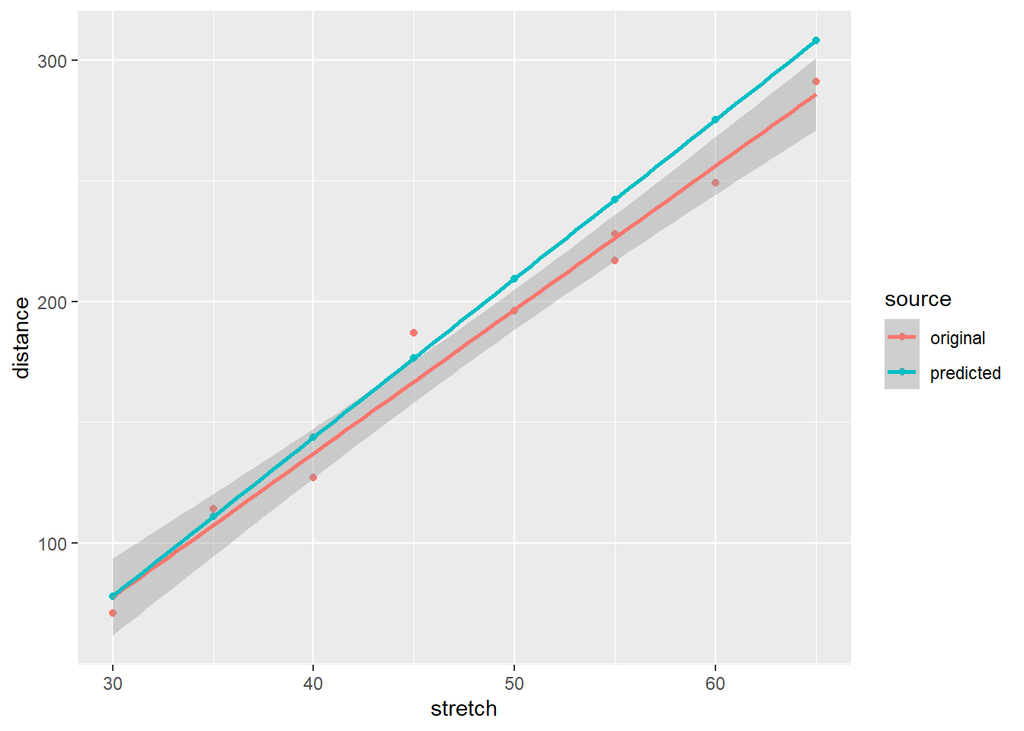

```r
dat1 <- data.frame(stretch = elastic2$stretch,
                   distance = c(elastic2$distance, pred)
)

dat1$source <- rep(c("original", "predicted"), each = nrow(elastic2))

dat1 %>%
  ggplot(aes(x = stretch, y = distance, colour = source)) +
  geom_point() +
  geom_smooth(method = "lm")
```

The predicted values are very similar to the observed values.

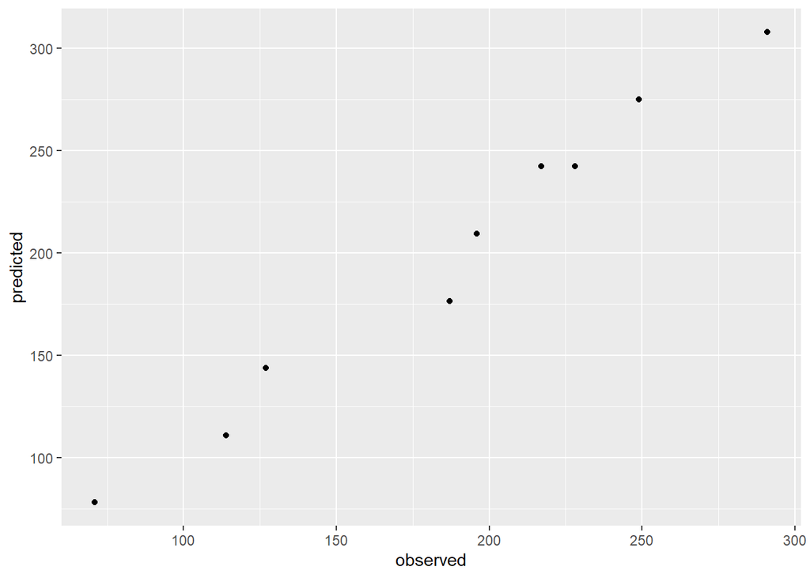

```r
dat1 <- data.frame(observed = elastic2$distance, predicted = pred)

dat1 %>%
  ggplot(aes(observed, predicted)) +
  geom_point()
```

The observed and predicted `distance` values are not identical because of two sources of error

1. We applied the `elastic1` model to `elastic2` data to generate the predictions
2. We are comparing predictions to observed values

Considering these points, the predictions are very accurate and have a remarkably high correlations with the observed values.

```r
dat1 %$% cor(observed, predicted)
```

```
## [1] 0.9903421
```

# 2 Analyzing `mammalsleep`

For the remaining questions in this practical, you will analyze the `mammalsleep` dataset. The `mammalsleep` dataset is part of the **mice** package. This dataset contains the Allison and Cicchetti (1976) data on mammalian species. To learn more about these data, call up the help file.

```r
?mammalsleep
```

## 2.1

**Regress brain weight onto body weight**

Use `lm()` to estimate a linear regression model wherein `brw` is predicted by `bw`.

- Inspect the fitted model.

```r
fit1 <- lm(brw ~ bw, data = mammalsleep)

summary(fit1)
```

```
##
## Call:
## lm(formula = brw ~ bw, data = mammalsleep)
##
## Residuals:
##     Min      1Q  Median      3Q     Max
## -810.07  -88.52  -79.64  -13.02 2050.33
##
## Coefficients:
##             Estimate Std. Error t value Pr(>|t|)
## (Intercept) 91.00440   43.55258    2.09   0.0409 *
## bw           0.96650    0.04766   20.28   <2e-16 ***
## ---
## Signif. codes:  0 '***' 0.001 '**' 0.01 '*' 0.05 '.' 0.1 ' ' 1
##
## Residual standard error: 334.7 on 60 degrees of freedom
## Multiple R-squared:  0.8727, Adjusted R-squared:  0.8705
## F-statistic: 411.2 on 1 and 60 DF,  p-value: < 2.2e-16
```

Body weight is a significant predictor of brain weight. If we inspect the model fit, we see that the $R^2$ is quite high and significantly greater than zero.

## 2.2

**Add `species` as a second predictor**

Add the `species` variable (as a predictor) into the model that you estimated in Question 2.1.

- Inspect the fitted model.

```r
fit2 <- update(fit1, ". ~ . + species")

summary(fit2)
```

```
##
## Call:
## lm(formula = brw ~ bw + species, data = mammalsleep)
##
## Residuals:
## ALL 62 residuals are 0: no residual degrees of freedom!
##
## Coefficients: (1 not defined because of singularities)
##                                   Estimate Std. Error t value Pr(>|t|)
## (Intercept)                        13.5316        NaN     NaN      NaN
## bw                                  0.8564        NaN     NaN      NaN
## speciesAfrican giant pouched rat   -7.7880        NaN     NaN      NaN
## speciesArctic Fox                  28.0695        NaN     NaN      NaN
## speciesArctic ground squirrel      -8.6195        NaN     NaN      NaN
## speciesAsian elephant            2408.2242        NaN     NaN      NaN
## speciesBaboon                     156.9334        NaN     NaN      NaN
## speciesBig brown bat              -13.2513        NaN     NaN      NaN
## speciesBrazilian tapir             18.4448        NaN     NaN      NaN
## speciesCat                          9.2423        NaN     NaN      NaN
## speciesChimpanzee                 381.7987        NaN     NaN      NaN
## speciesChinchilla                  -7.4956        NaN     NaN      NaN
## speciesCow                         11.2436        NaN     NaN      NaN
## speciesDesert hedgehog            -11.6026        NaN     NaN      NaN
## speciesDonkey                     245.2365        NaN     NaN      NaN
## speciesEastern American mole      -12.3958        NaN     NaN      NaN
## speciesEchidna                      8.8992        NaN     NaN      NaN
## speciesEuropean hedgehog          -10.7039        NaN     NaN      NaN
## speciesGalago                      -8.7029        NaN     NaN      NaN
## speciesGenet                        2.7609        NaN     NaN      NaN
## speciesGiant armadillo             16.0846        NaN     NaN      NaN
## speciesGiraffe                    213.4342        NaN     NaN      NaN
## speciesGoat                        77.7805        NaN     NaN      NaN
## speciesGolden hamster             -12.6344        NaN     NaN      NaN
## speciesGorilla                    215.1941        NaN     NaN      NaN
## speciesGray seal                  238.6746        NaN     NaN      NaN
## speciesGray wolf                   74.8555        NaN     NaN      NaN
## speciesGround squirrel             -9.6181        NaN     NaN      NaN
## speciesGuinea pig                  -8.9222        NaN     NaN      NaN
## speciesHorse                      195.2854        NaN     NaN      NaN
## speciesJaguar                      57.8287        NaN     NaN      NaN
```

[output cut: 21 more lines]

```
## speciesRock hyrax (Procavia hab)    4.3854        NaN     NaN      NaN
## speciesRoe deer                    71.9680        NaN     NaN      NaN
## speciesSheep                      113.9384        NaN     NaN      NaN
## speciesSlow loris                  -2.2305        NaN     NaN      NaN
## speciesStar nosed mole            -12.5830        NaN     NaN      NaN
## speciesTenrec                     -11.7023        NaN     NaN      NaN
## speciesTree hyrax                  -2.9444        NaN     NaN      NaN
## speciesTree shrew                 -11.1207        NaN     NaN      NaN
## speciesVervet                      40.8801        NaN     NaN      NaN
## speciesWater opossum              -12.6290        NaN     NaN      NaN
## speciesYellow-bellied marmot            NA         NA      NA       NA
##
## Residual standard error: NaN on 0 degrees of freedom
## Multiple R-squared:      1,  Adjusted R-squared:    NaN
## F-statistic:   NaN on 61 and 0 DF,  p-value: NA
```

Here, we use the `update()` function because we only want to add another predictor to an existing model and refit the larger model to the same data.

- The `update()` function allows us to make changes to an existing model and refit the model without having to respecify the entire formula.
  - This approach can be very useful when dealing with large, complex models that you just want to tweak a little bit.
  - We can also use `update()` to refit the same model to a different dataset.

Our new model looks pretty broken.

- The model fits the data perfectly.
  - All residuals are 0.
- We don’t get any standard error estimates (consequently, we get no t-values or p-values, either).

```r
table(mammalsleep$species)
```

```
##
##          African elephant African giant pouched rat                Arctic Fox
##                         1                         1                         1
##    Arctic ground squirrel            Asian elephant                    Baboon
##                         1                         1                         1
##             Big brown bat           Brazilian tapir                       Cat
##                         1                         1                         1
##                Chimpanzee                Chinchilla                       Cow
##                         1                         1                         1
##           Desert hedgehog                    Donkey     Eastern American mole
##                         1                         1                         1
##                   Echidna         European hedgehog                    Galago
##                         1                         1                         1
##                     Genet           Giant armadillo                   Giraffe
##                         1                         1                         1
##                      Goat            Golden hamster                   Gorilla
##                         1                         1                         1
##                 Gray seal                 Gray wolf           Ground squirrel
##                         1                         1                         1
##                Guinea pig                     Horse                    Jaguar
##                         1                         1                         1
##                  Kangaroo Lesser short-tailed shrew          Little brown bat
##                         1                         1                         1
##                       Man                  Mole rat           Mountain beaver
##                         1                         1                         1
##                     Mouse                Musk shrew       N. American opossum
##                         1                         1                         1
##     Nine-banded armadillo                     Okapi                Owl monkey
##                         1                         1                         1
##              Patas monkey                Phanlanger                       Pig
##                         1                         1                         1
##                    Rabbit                   Raccoon                       Rat
##                         1                         1                         1
##                   Red fox             Rhesus monkey    Rock hyrax (Hetero. b)
##                         1                         1                         1
## Rock hyrax (Procavia hab)                  Roe deer                     Sheep
##                         1                         1                         1
##                Slow loris           Star nosed mole                    Tenrec
##                         1                         1                         1
##                Tree hyrax                Tree shrew                    Vervet
##                         1                         1                         1
##             Water opossum     Yellow-bellied marmot
##                         1                         1
```

If we calculate the frequencies of the `species` variable, we see that every animal is observed only once. Adding species as a predictor, therefore, yields a perfectly fitting model (i.e., a model wherein the regression line touches every data point.

- Such a model has no residual variance.
- We cannot use a perfectly fitting model for statistical inference.
- Nor should we use a perfectly fitting model for prediction.

We should omit the `species` variable and account for the between-species variability via the residual variance.

# 3 Model Building

Can you use the `mammalsleep` dataset to specify a (sensible) linear model that explains more variability in `brw` than `bw` explains as the only predictor?

## 3.1

**Variable selection**

Use some statistical rationale to select a set of additional predictors that will improve the fit of the model you estimated in Question 2.1.

- Try to choose predictors that are actually “pulling their weight” and explaining a substantial proportion of additional variability in `brw`.

There are many ways that you could go about this task, but we’ll employ a “quick-and-dirty” method based on bivariate correlations. Since the regression coefficients and the $R^2$ are both fancy flavors of correlations (i.e., semi-partial correlations and squared multiple correlation, respectively), we can get a sense for which variables are likely to be good predictors by scrutinizing the bivariate correlations between the candidate variables and the outcome.

```r
(
  corMat <- mammalsleep %>%
    subset(select = -species) %>% # Exclude the species factor
    cor(use = "pairwise.complete.obs") %>% # Use pairwise deletion to work around missing data
    round(3)
)
```

```
##         bw    brw    sws     ps     ts    mls     gt     pi    sei    odi
## bw   1.000  0.934 -0.376 -0.109 -0.307  0.302  0.651  0.059  0.338  0.134
## brw  0.934  1.000 -0.369 -0.105 -0.358  0.509  0.747  0.034  0.368  0.146
## sws -0.376 -0.369  1.000  0.514  0.963 -0.384 -0.595 -0.318 -0.544 -0.484
## ps  -0.109 -0.105  0.514  1.000  0.727 -0.296 -0.451 -0.447 -0.537 -0.579
## ts  -0.307 -0.358  0.963  0.727  1.000 -0.410 -0.631 -0.396 -0.642 -0.588
## mls  0.302  0.509 -0.384 -0.296 -0.410  1.000  0.615 -0.103  0.360  0.062
## gt   0.651  0.747 -0.595 -0.451 -0.631  0.615  1.000  0.201  0.638  0.379
## pi   0.059  0.034 -0.318 -0.447 -0.396 -0.103  0.201  1.000  0.618  0.916
## sei  0.338  0.368 -0.544 -0.537 -0.642  0.360  0.638  0.618  1.000  0.787
## odi  0.134  0.146 -0.484 -0.579 -0.588  0.062  0.379  0.916  0.787  1.000
```

This matrix contains quite a lot of information that we don’t need for our variable selection task. To obtain only the correlations with `brw`, we can select the relevant column.

```r
corMat %>% subset(select = brw)
```

```
##        brw
## bw   0.934
## brw  1.000
## sws -0.369
## ps  -0.105
## ts  -0.358
## mls  0.509
## gt   0.747
## pi   0.034
## sei  0.368
## odi  0.146
```

The following variables all have moderate to large correlations with `brw`:

- `sws`: short wave sleep
- `ts` : total sleep
- `mls`: maximum life span
- `gt` : gestation time
- `sei`: sleep exposure index

However, from the larger correlation matrix, we can also see that `ts` is strongly correlated with `sws`.

- In fact, `ts` is calculated as the sum of `sws` and `ps`.

Including both the `ts` and `sws` variables will not hurt the $R^2$, but doing so will decrease the precision of our estimates (i.e., produce larger standard errors).

It may be wise to select `sws` as a predictor because `ts` contains a source of error, in the form of `ps`. So, the linear association between `brw` and `ts` will be slightly weaker than the linear association between `sws` and `brw`. That being said, `sws` is missing 14 cases whereas `ts` is missing only 4 cases.

```r
summary(mammalsleep)
```

```
##                       species         bw                brw
##  African elephant         : 1   Min.   :   0.005   Min.   :   0.14
##  African giant pouched rat: 1   1st Qu.:   0.600   1st Qu.:   4.25
##  Arctic Fox               : 1   Median :   3.342   Median :  17.25
##  Arctic ground squirrel   : 1   Mean   : 198.790   Mean   : 283.13
##  Asian elephant           : 1   3rd Qu.:  48.202   3rd Qu.: 166.00
##  Baboon                   : 1   Max.   :6654.000   Max.   :5712.00
##  (Other)                  :56
##       sws               ps              ts             mls
##  Min.   : 2.100   Min.   :0.000   Min.   : 2.60   Min.   :  2.000
##  1st Qu.: 6.250   1st Qu.:0.900   1st Qu.: 8.05   1st Qu.:  6.625
##  Median : 8.350   Median :1.800   Median :10.45   Median : 15.100
##  Mean   : 8.673   Mean   :1.972   Mean   :10.53   Mean   : 19.878
##  3rd Qu.:11.000   3rd Qu.:2.550   3rd Qu.:13.20   3rd Qu.: 27.750
##  Max.   :17.900   Max.   :6.600   Max.   :19.90   Max.   :100.000
##  NA's   :14       NA's   :12      NA's   :4       NA's   :4
##        gt               pi             sei             odi
##  Min.   : 12.00   Min.   :1.000   Min.   :1.000   Min.   :1.000
##  1st Qu.: 35.75   1st Qu.:2.000   1st Qu.:1.000   1st Qu.:1.000
##  Median : 79.00   Median :3.000   Median :2.000   Median :2.000
##  Mean   :142.35   Mean   :2.871   Mean   :2.419   Mean   :2.613
##  3rd Qu.:207.50   3rd Qu.:4.000   3rd Qu.:4.000   3rd Qu.:4.000
##  Max.   :645.00   Max.   :5.000   Max.   :5.000   Max.   :5.000
##  NA's   :4
```

Since our total sample size is only 62, the loss of 10 more cases is a substantial problem. Therefore, `ts` is a much better candidate, despite its weaker association with the outcome.

So, our new predictors will be:

- `bw`
- `ts`
- `mls`
- `gt`
- `sei`

## 3.2

**Estimate the new model**

Regress `brw` onto your selected predictors.

- Inspect the fitted model.

```r
fit3 <- update(fit1, ". ~ . + ts + mls + gt + sei")

summary(fit3)
```

```
##
## Call:
## lm(formula = brw ~ bw + ts + mls + gt + sei, data = mammalsleep)
##
## Residuals:
##     Min      1Q  Median      3Q     Max
## -485.56 -100.64    0.64  104.72 1434.27
##
## Coefficients:
##               Estimate Std. Error t value Pr(>|t|)
## (Intercept) -197.18186  198.55848  -0.993 0.325987
## bw             0.81023    0.05633  14.383  < 2e-16 ***
## ts             4.90058   11.88823   0.412 0.682134
## mls           10.58363    2.69053   3.934 0.000287 ***
## gt             1.23352    0.58171   2.121 0.039509 *
## sei          -43.36629   34.80674  -1.246 0.219243
## ---
## Signif. codes:  0 '***' 0.001 '**' 0.01 '*' 0.05 '.' 0.1 ' ' 1
##
## Residual standard error: 268.8 on 45 degrees of freedom
##   (11 observations deleted due to missingness)
## Multiple R-squared:  0.9373, Adjusted R-squared:  0.9304
## F-statistic: 134.6 on 5 and 45 DF,  p-value: < 2.2e-16
```

### 3.2.1 Coefficient Estimates

Notice that the regression coefficients associated with `ts` and `sei` are both nonsignificant, even though both of these variables have moderately strong and significant bivariate correlations with `brw`.

```r
mammalsleep %$% cor.test(brw, ts)
```

```
##
##  Pearson's product-moment correlation
##
## data:  brw and ts
## t = -2.8701, df = 56, p-value = 0.00578
## alternative hypothesis: true correlation is not equal to 0
## 95 percent confidence interval:
##  -0.5642105 -0.1099789
## sample estimates:
##       cor
## -0.358102
```

```r
mammalsleep %$% cor.test(brw, sei)
```

```
##
##  Pearson's product-moment correlation
##
## data:  brw and sei
## t = 3.0637, df = 60, p-value = 0.003272
## alternative hypothesis: true correlation is not equal to 0
## 95 percent confidence interval:
##  0.129972 0.565609
## sample estimates:
##       cor
## 0.3678004
```

This incongruity is the effect of partialling between the predictors.

- Even though both `ts` and `sei` are linearly associated with `brw`, the aspects of `brw` explained by `ts` and `sei` are (mostly) also explained by `mls` and `gt`.
- After accounting for the effects of `mls` and `gt`, `ts` and `sei` cannot explain much variability in `brw`.

Partialling is one of the primary reasons to use multiple linear regression instead of multiple bivariate correlations.

- If the predictors are correlated, the bivariate correlations can produce misleading results.

### 3.2.2 Model Fit

The $R^2$ from our new model is indeed higher than the $R^2$ from the model with `bw` as the only predictor (0.937 vs. 0.873). So our new model explains a larger proportion of variability in `brw`.

Unfortunately, we cannot use the `anova()` function to test if our new model explains *significantly more* variability in `brw` that the model from 2.1.

```r
anova(fit1, fit3)
```

```
## Error in anova.lmlist(object, ...): models were not all fitted to the same size of dataset
```

The use of listwise deletion to work around the missing data has deleted 11 cases when estimating the larger model. Since the models were not estimated from the same data, they are not nested and cannot be compared with a $\Delta R^2$ test.

Although we can compute AIC values for each of these models, comparing the two AIC values is again invalid because the models were fit to different datasets.

```r
AIC(fit1, fit3)
```

```
##      df      AIC
## fit1  3 900.7638
## fit3  7 722.9488
```

# 4 Assumption Checking

## 4.1

**Inspect diagnostic plots**

Use the `plot()` function to generate diagnostic plots for the model you estimated in 3.2.

- What issues, if any, can you detect?

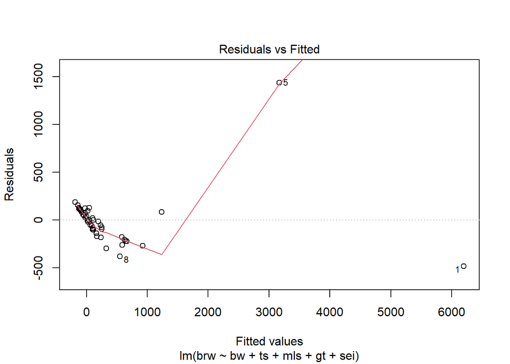

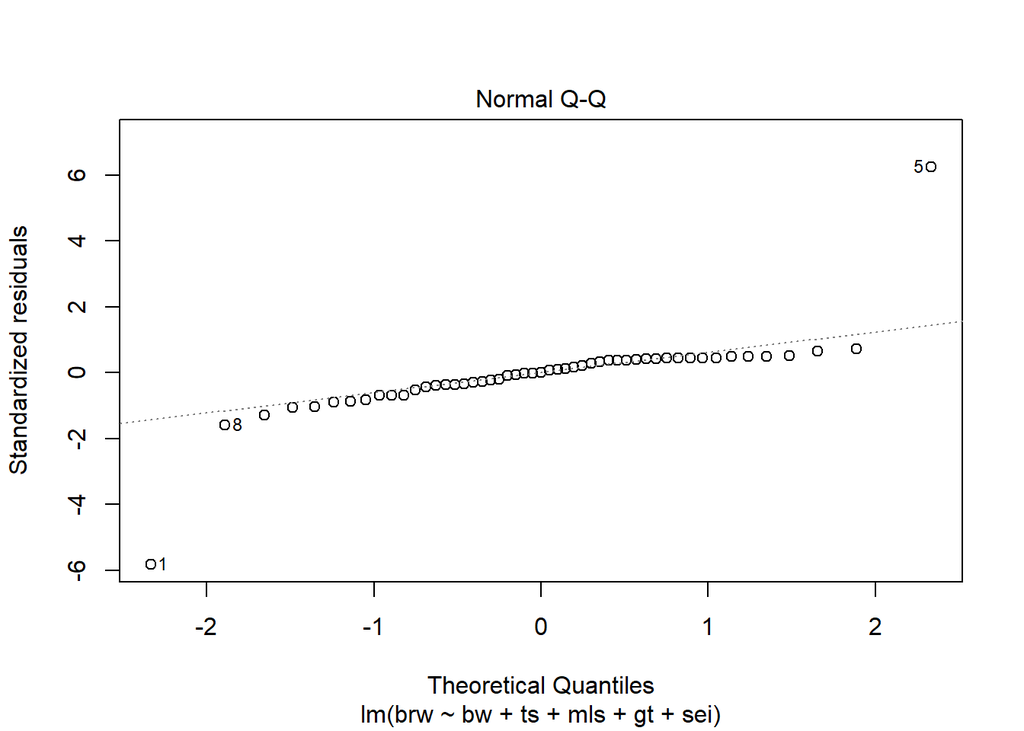

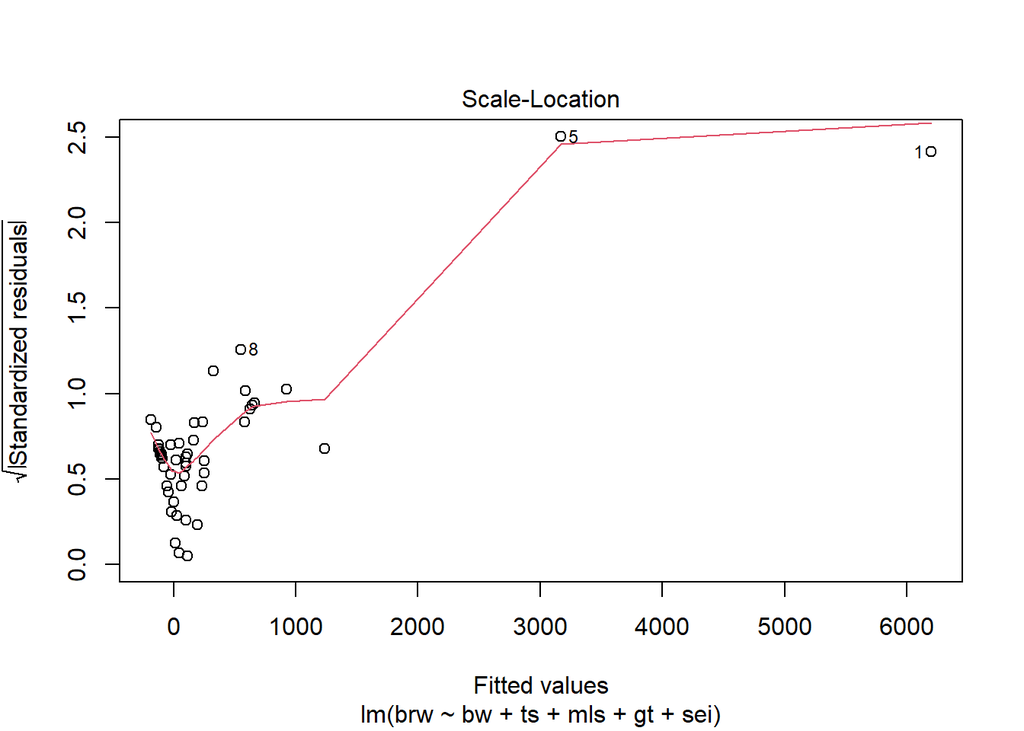

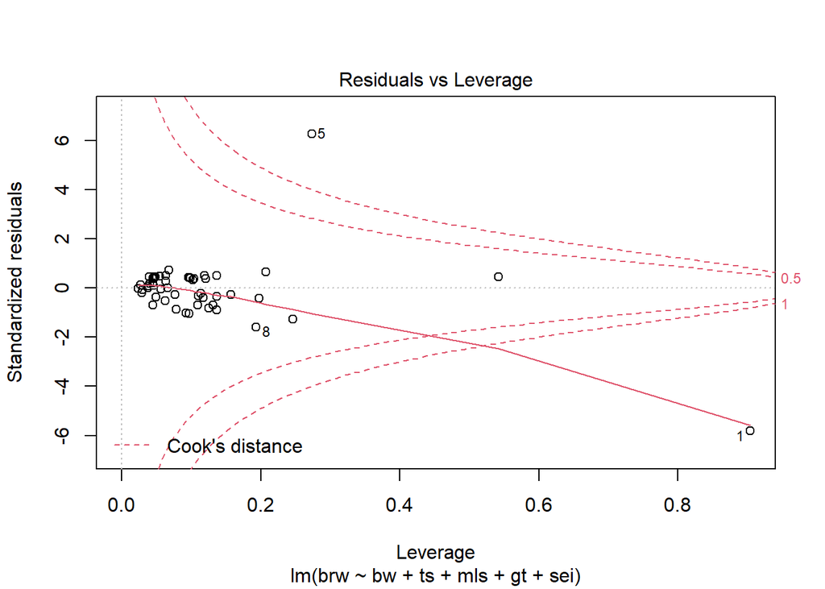

```r
plot(fit3)
```

Cases 1 and 5 both seem to be highly influential.

- Case 1 has very high leverage.
- Case 5 looks like an outlier (with a large positive residual).

Assessing the tenability of the model assumptions doesn’t make any sense until we address these influential cases.

### 4.1.1 Further Detective Work

Let’s see who’s causing all the problems:

```r
mammalsleep$species[c(1, 5)]
```

```
## [1] African elephant Asian elephant
## 62 Levels: African elephant African giant pouched rat ... Yellow-bellied marmot
```

And, what’s so special about these trouble-makers?

```r
mammalsleep[c(1, 5), c("species", "brw", "bw", "ts", "mls", "gt", "sei")]
```

```
##            species  brw   bw  ts  mls  gt sei
## 1 African elephant 5712 6654 3.3 38.6 645   5
## 5   Asian elephant 4603 2547 3.9 69.0 624   5
```

Well, they’re both big boys, for sure. The very large brain and body weights for the two elephant species strongly influence the model.

- For the African Elephant, the massive body weight produces high leverage.
- For the Asian Elephant, the very large brain weight relative to the body weight produces an outlier.

Notice that the residual for Case 1 (African Elephant) is smaller than the residual for Case 5 (Asian Elephant), even though the brain weight for Case 1 is larger than the brain weight for Case 5.

- Due to the huge body weight, the model expects the African Elephant to have a very large brain.
- The Asian Elephant, on the other hand, has an unexpectedly large brain for its relatively small body.

```r
residuals(fit3)
```

```
##            1            2            3            5            6            7
## -485.5560450  106.2290991   -1.1334890 1434.2683263  -14.2173431  -99.9739636
##            8            9           10           11           12           14
## -382.2870299 -138.2708329 -222.1389154  103.2062362 -222.9813136 -207.3502817
##           15           16           17           18           22           23
##  111.6721285 -299.3810807  119.0327425  -21.7754459   93.7473544  109.8701136
##           24           25           26           27           28           29
## -176.6595017 -263.2907467   17.7387559   47.0471717  127.4386770 -268.6348480
##           30           32           33           34           37           38
##  -96.8256901  185.4170567 -172.4144182   83.3979884  118.9373998  119.9390604
##           39           40           42           43           44           45
##   82.6791039  -53.5732527  -83.9801061    0.6414618   24.9406553  -73.6937449
##           46           47           48           49           50           51
##  154.1785525   35.6757062  101.8866990   71.6287560  -55.4961698  -88.3634693
##           52           53           54           55           57           58
##  -65.5082879  122.5071227  127.4900821   -4.0547720   55.6039203 -101.3157666
##           59           60           61
##  127.8168865 -181.6354614   97.5209191
```

We can get a sense for how much these cases are affecting the results by examining the influence statistics.

```r
influence(fit3)
```

```
## $hat
##          1          2          3          5          6          7          8
## 0.90376652 0.09680085 0.03820138 0.27344636 0.05622069 0.11707227 0.19346612
##          9         10         11         12         14         15         16
## 0.06299083 0.13658848 0.09859497 0.07869705 0.12546971 0.09609692 0.24598832
##         17         18         22         23         24         25         26
## 0.03973070 0.03019447 0.12099853 0.04617505 0.10988139 0.09296178 0.03795117
##         27         28         29         30         32         33         34
## 0.04105129 0.05488669 0.09677947 0.04907583 0.06803407 0.13168851 0.54221947
##         37         38         39         40         42         43         44
## 0.04692941 0.04828122 0.10241613 0.11430997 0.11037221 0.06662589 0.04627464
##         45         46         47         48         49         50         51
## 0.07663133 0.20760998 0.02767828 0.04517846 0.06359325 0.02915966 0.13663756
##         52         53         54         55         57         58         59
## 0.15726711 0.13674991 0.11930401 0.02387457 0.04466402 0.19821965 0.06384060
```

[output cut: 144 more lines]

From these statistics, we can conclude:

- Case 1 (African Elephant) has a very high leverage (as seen in the `$hat` section).
- The residual standard deviation would decrease if we exclude Cases 1 and 5 (as seen in the `$sigma` section).
- The coefficients would change dramatically if we exclude Cases 1 and 5 (as seen in the `$coefficients` section).

The information in the `$coefficients` section is equivalent to the output of the `dfbeta()` function.:

```r
head(influence(fit3)$coefficients)
```

```
##     (Intercept)            bw           ts           mls            gt
## 1 -243.72029374 -7.891619e-01  8.300378873  1.961265e+00  1.213301e+00
## 2   25.21936417  1.413647e-03 -1.206573436 -7.335218e-02 -1.813002e-02
## 3   -0.08631166 -6.519435e-06  0.001850449 -8.986121e-05  6.447977e-05
## 5 -222.37630813 -3.864155e-03  9.482902916  1.328092e+00  1.088658e+00
## 6    1.23516961  1.979373e-04 -0.063616829 -4.345374e-03 -1.847447e-04
## 7   15.38832782 -5.432214e-04 -1.324156374 -9.241778e-02  8.203378e-04
##           sei
## 1  9.81613002
## 2 -2.72951278
## 3  0.01557169
## 5 -7.18465245
## 6 -0.32753933
## 7 -0.83130974
```

```r
head(dfbeta(fit3))
```

```
##     (Intercept)            bw           ts           mls            gt
## 1 -243.72029374 -7.891619e-01  8.300378873  1.961265e+00  1.213301e+00
## 2   25.21936417  1.413647e-03 -1.206573436 -7.335218e-02 -1.813002e-02
## 3   -0.08631166 -6.519435e-06  0.001850449 -8.986121e-05  6.447977e-05
## 5 -222.37630813 -3.864155e-03  9.482902916  1.328092e+00  1.088658e+00
## 6    1.23516961  1.979373e-04 -0.063616829 -4.345374e-03 -1.847447e-04
## 7   15.38832782 -5.432214e-04 -1.324156374 -9.241778e-02  8.203378e-04
##           sei
## 1  9.81613002
## 2 -2.72951278
## 3  0.01557169
## 5 -7.18465245
## 6 -0.32753933
## 7 -0.83130974
```

# 5 Warning

The variable selection and model building procedure illustrated above has only produced a candidate model. We cannot use the model estimated in Question 3.2 for inference or prediction.

- This model almost certainly overfits the data.
- We have used the same dataset for variable selection and model estimation.

In general, we cannot use the same data for exploratory and confirmatory analyses.

- In this sense, examples of exploratory analyses include:
  - Variable/model selection
  - Parameter tuning
  - Post hoc model modifications (i.e., modifying a model based on the model’s estimates)
- Examples of confirmatory analyses include:
  - Estimating population parameters
  - Making statistical inferences about population parameters
  - Quantifying prediction error

In the above example, we used the `mammalsleep` data to calculate bivariate correlations with which we selected the predictors. We then estimated a model using the same data.

- The estimates from this model (the one we fit in Question 3.2) are not valid estimates of the population parameters of our model.
- By using the same data to select the variables of our model and estimate the model, we’re “double-dipping” in the data.
  - If we “ask” the data to tell us which variables are the best predictors, how can we then use the same data to confirm that those variables truly are meaningful predictors?
  - Data are not susceptable to psychological tricks. If we “ask” the data the same question twice, we’ll get the same answer (even if we use two different phrasings).
    - Pretending that we’ve “asked” two different questions, when we’ve really only employed two different phrasings of the same question, will lead to invalid results and erroneous conclusions.
  - What we want to do is “ask” the same question of two different datasets.
    - We need to confirm our exploratory findings on new data.

All of these caveats do not make the variable selection procedure demonstrated above wrong or useless; the procedure is perfectly fine. We can even use the results of the fitted regression model from Question 3.2 to make decisions about further model modifications (e.g., maybe we want to drop the `ts` and `sei` variables).

- This whole process must be viewed as an exploratory model-building process, though.
- We must confirm our final model (whatever it looks like) on a new sample!

## 5.1

**Positive affirmation**

Look at your reflection in a mirror, and repeat the following statement three times.

> I am a good person. I do not run exploratory and confirmatory analyses on the same data.

End of Exercise 7